# Prediction Assignment

Keith Krause

4/17/2020

## Project Overview

This project utilizes the data from personal activity devices to quantify movement. Utilizing data provided courtesy of Ugulino, W.; Cardador, D.; Vega, K.; Velloso, E.; Milidiu, R.; Fuks, H. *Wearable Computing: Accelerometers’ Data Classification of Body Postures and Movements* , we will attempt to predict the manner of how a participant performed the exercise. The data includes accelerometers on the belt, forearm, arm and dumbell on each of the six participants. They performed barbell lifts correctly and incorrectly in five different ways. A training data set will be used to build the model with a seperate test data set to validate the model at the end.

## Package Loading

The below packages were used in this project.

```r
library(caret)
library(rpart)
```

```r
library(rpart.plot)
library(RColorBrewer)
library(rattle)
library(randomForest)
library(knitr)
```

## Load Data

```r
trainUrl <- "http://d396qusza40orc.cloudfront.net/predmachlearn/pml-training.csv"
testUrl <- "http://d396qusza40orc.cloudfront.net/predmachlearn/pml-testing.csv"

training <- read.csv(url(trainUrl), na.strings=c("NA","#DIV/0!",""))
testing <- read.csv(url(testUrl), na.strings=c("NA","#DIV/0!",""))

dim(training)
```

```
## [1] 19622   160
```

```r
dim(testing)
```

```
## [1]  20 160
```

There are 19622 observation with 160 vaiables in the training dataset.

## Clean the Data

All NA and empty values are removed from the datasets.

```r
training<- training[, colSums(is.na(training)) == 0]
testing <- testing[, colSums(is.na(testing)) == 0]
dim(training)
```

```
## [1] 19622    60
```

```r
dim(testing)
```

```
## [1] 20 60
```

Remove the first seven variables that do not have an impact on **classe** variable.

```r
training<- training[,-c(1:7)]
testing<- testing[,-c(1:7)]
dim(training)
```

```
## [1] 19622    53
```

```r
dim(testing)
```

```
## [1] 20 53
```

## Prediction Preperation

```r
set.seed(12345)
inTrain<- createDataPartition(training$classe, p = 0.7, list = FALSE)
training <- training[inTrain, ]
traintest <- training[-inTrain, ]
dim(training)
```

```
## [1] 13737    53
```

```r
dim(traintest)
```

```
## [1] 4140   53
```

## Model Building

### Classification Tree

Obtain the model and plot the classification tree.

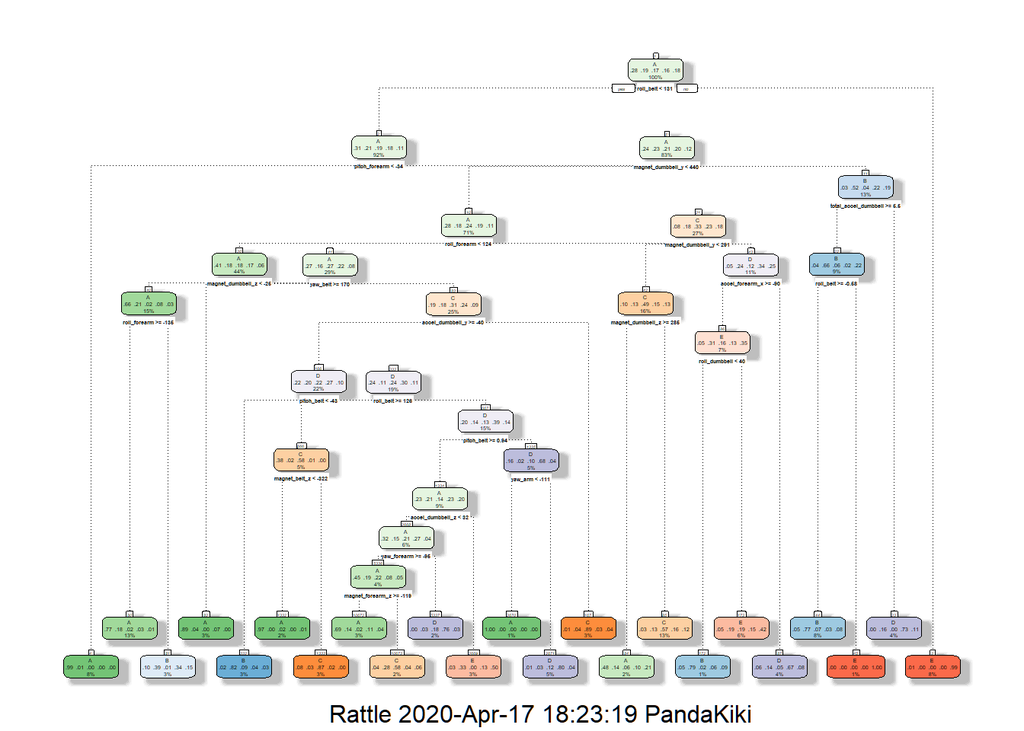

```r
modFit1 <- rpart(classe ~ ., data=training, method="class")
fancyRpartPlot(modFit1)
```

Validate the model by using the set aside test data, **traintest**, to see how it performs based on its accuracy variable.

```r
predictions1 <- predict(modFit1, traintest, type = "class")
cmtree <- confusionMatrix(predictions1, traintest$classe)
cmtree
```

```
## Confusion Matrix and Statistics
##
##           Reference
## Prediction    A    B    C    D    E
##          A 1086  134   12   46   28
##          B   30  438   40   42   54
##          C   27  103  589  106   81
##          D   11   53   43  406   40
##          E   18   70   39   53  591
##
## Overall Statistics
##
##                Accuracy : 0.7512
##                  95% CI : (0.7377, 0.7643)
##     No Information Rate : 0.2831
##     P-Value [Acc > NIR] : < 2.2e-16
##
##                   Kappa : 0.6841
##
##  Mcnemar's Test P-Value : < 2.2e-16
##
## Statistics by Class:
##
##                      Class: A Class: B Class: C Class: D Class: E
## Sensitivity            0.9266   0.5489   0.8147  0.62175   0.7443
## Specificity            0.9259   0.9503   0.9072  0.95784   0.9462
## Pos Pred Value         0.8315   0.7252   0.6501  0.73418   0.7665
## Neg Pred Value         0.9697   0.8982   0.9586  0.93114   0.9397
## Prevalence             0.2831   0.1928   0.1746  0.15773   0.1918
## Detection Rate         0.2623   0.1058   0.1423  0.09807   0.1428
## Detection Prevalence   0.3155   0.1459   0.2188  0.13357   0.1862
## Balanced Accuracy      0.9262   0.7496   0.8609  0.78979   0.8453
```

We then plot the matrix results to see that it has a low *accuracy rating of 0.7512* and there for has a considerable *out of sample error of approximately 0.2488*.

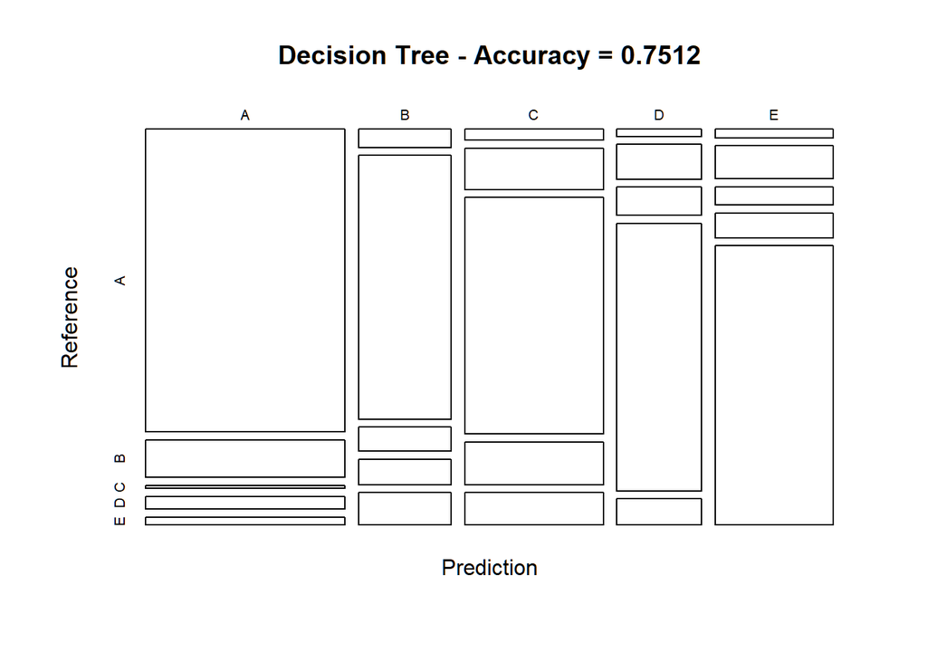

```r
plot(cmtree$table, col = cmtree$byClass, main = paste("Decision Tree - Accuracy =", round(cmtree$overall['Accuracy'], 4)))
```

### Random Forests

```r
modFit2<- randomForest(classe ~ ., data = training)
predictions2<- predict(modFit2, traintest, type= "class")
cmrf<- confusionMatrix(predictions2, traintest$classe)
cmrf
```

```
## Confusion Matrix and Statistics
##
##           Reference
## Prediction    A    B    C    D    E
##          A 1172    0    0    0    0
##          B    0  798    0    0    0
##          C    0    0  723    0    0
##          D    0    0    0  653    0
##          E    0    0    0    0  794
##
## Overall Statistics
##
##                Accuracy : 1
##                  95% CI : (0.9991, 1)
##     No Information Rate : 0.2831
##     P-Value [Acc > NIR] : < 2.2e-16
##
##                   Kappa : 1
##
##  Mcnemar's Test P-Value : NA
##
## Statistics by Class:
##
##                      Class: A Class: B Class: C Class: D Class: E
## Sensitivity            1.0000   1.0000   1.0000   1.0000   1.0000
## Specificity            1.0000   1.0000   1.0000   1.0000   1.0000
## Pos Pred Value         1.0000   1.0000   1.0000   1.0000   1.0000
## Neg Pred Value         1.0000   1.0000   1.0000   1.0000   1.0000
## Prevalence             0.2831   0.1928   0.1746   0.1577   0.1918
## Detection Rate         0.2831   0.1928   0.1746   0.1577   0.1918
## Detection Prevalence   0.2831   0.1928   0.1746   0.1577   0.1918
## Balanced Accuracy      1.0000   1.0000   1.0000   1.0000   1.0000
```

Plot the model

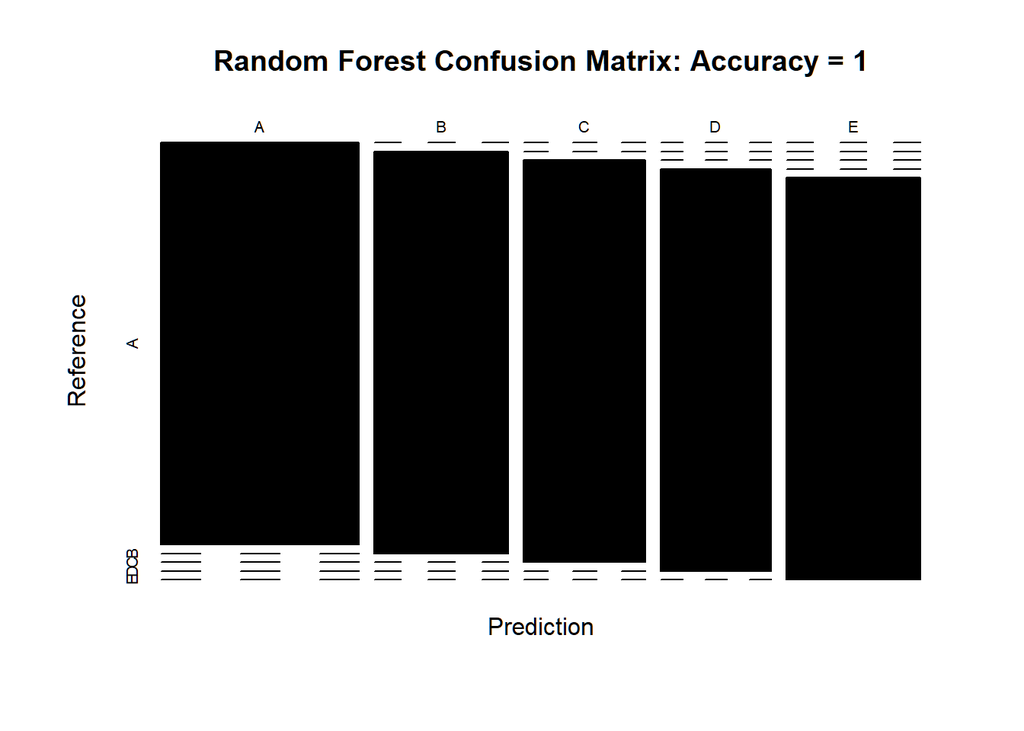

```r
plot(cmrf$table, col = cmrf$byClass, main = paste("Random Forest Confusion Matrix: Accuracy =", round(cmrf$overall['Accuracy'], 4)))
```

### Prediction with Generalized Boosted Regression

```r
controlGBM <- trainControl(method = "repeatedcv", number = 5, repeats = 1)
modFit3  <- train(classe ~ ., data=training, method = "gbm", trControl = controlGBM, verbose = FALSE)
modFit3$finalModel
```

```
## A gradient boosted model with multinomial loss function.
## 150 iterations were performed.
## There were 52 predictors of which 52 had non-zero influence.
```

Print the General Boosted Regression Model summary

```r
print(modFit3)
```

```
## Stochastic Gradient Boosting
##
## 13737 samples
##    52 predictor
##     5 classes: 'A', 'B', 'C', 'D', 'E'
##
## No pre-processing
## Resampling: Cross-Validated (5 fold, repeated 1 times)
## Summary of sample sizes: 10989, 10989, 10989, 10990, 10991
## Resampling results across tuning parameters:
##
##   interaction.depth  n.trees  Accuracy   Kappa
##   1                   50      0.7519106  0.6853967
##   1                  100      0.8215774  0.7741344
##   1                  150      0.8548457  0.8163274
##   2                   50      0.8559371  0.8174977
##   2                  100      0.9069672  0.8822965
##   2                  150      0.9325912  0.9147048
##   3                   50      0.8969940  0.8696135
##   3                  100      0.9419819  0.9265975
##   3                  150      0.9601810  0.9496286
##
## Tuning parameter 'shrinkage' was held constant at a value of 0.1
##
## Tuning parameter 'n.minobsinnode' was held constant at a value of 10
## Accuracy was used to select the optimal model using the largest value.
## The final values used for the model were n.trees = 150, interaction.depth =
##  3, shrinkage = 0.1 and n.minobsinnode = 10.
```

The final values used for the model were n.trees = 150, interaction.depth = 3, shrinkage = 0.1 and n.minobsinnode = 10

Validate the model

```r
predictions3 <- predict(modFit3, newdata=traintest)
cmGBM <- confusionMatrix(predictions3, traintest$classe)
cmGBM
```

```
## Confusion Matrix and Statistics
##
##           Reference
## Prediction    A    B    C    D    E
##          A 1159   18    0    1    1
##          B    5  767   18    1    5
##          C    5   12  701   21    2
##          D    2    1    4  628    9
##          E    1    0    0    2  777
##
## Overall Statistics
##
##                Accuracy : 0.9739
##                  95% CI : (0.9686, 0.9786)
##     No Information Rate : 0.2831
##     P-Value [Acc > NIR] : < 2.2e-16
##
##                   Kappa : 0.967
##
##  Mcnemar's Test P-Value : 5.899e-05
##
## Statistics by Class:
##
##                      Class: A Class: B Class: C Class: D Class: E
## Sensitivity            0.9889   0.9612   0.9696   0.9617   0.9786
## Specificity            0.9933   0.9913   0.9883   0.9954   0.9991
## Pos Pred Value         0.9830   0.9636   0.9460   0.9752   0.9962
## Neg Pred Value         0.9956   0.9907   0.9935   0.9928   0.9949
## Prevalence             0.2831   0.1928   0.1746   0.1577   0.1918
## Detection Rate         0.2800   0.1853   0.1693   0.1517   0.1877
## Detection Prevalence   0.2848   0.1923   0.1790   0.1556   0.1884
## Balanced Accuracy      0.9911   0.9762   0.9789   0.9786   0.9888
```

Plot the model

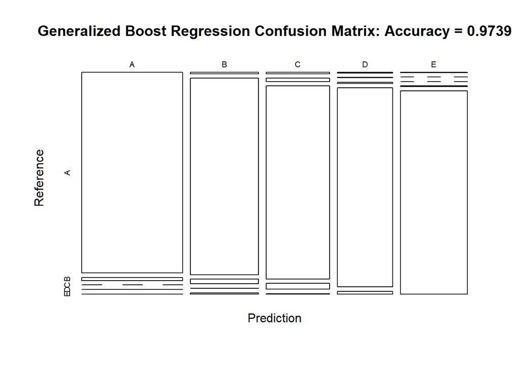

```r
plot(cmGBM$table, col = cmGBM$byClass, main = paste("Generalized Boost Regression Confusion Matrix: Accuracy =", round(cmGBM$overall['Accuracy'], 4)))
```

The *accuracy rate is 0.9739* for the Generalized Boosted Regression Model. It has an *out of sample error of .0261*

## Best Prediction Model for Test Data

Based on the accuracy rates of the three models, it can be determined that the second model, Random Forest, is the best model to predict the outcomes. We will now use the test data to vaidate it.

```r
TestPrediction<- predict(modFit2, newdata = testing)
TestPrediction
```

```
##  1  2  3  4  5  6  7  8  9 10 11 12 13 14 15 16 17 18 19 20
##  B  A  B  A  A  E  D  B  A  A  B  C  B  A  E  E  A  B  B  B
## Levels: A B C D E
```

The results of the TestPrediction will be submitted to the *Course Project Prediction Quiz*.